# Extract Transform Load - ACO

Karen Jiang

2/26/2020

## ACO Dataset

We are examining 3 datasets from CMS.

- **ACO general information**
- Beneficiaries information by ACO
- Fee-for-Service Expenditures by ACO

This dataset provides information about the ACO and information around their performance for 2018. Each row (observation), is a single ACO.

To better understand how MSSP scoring and classifications for ACOs, information can be found in the MSSP Shared Savings and Losses Assignement and Methodology.

### Tracks

In 2018, there were four Tracks that an ACO could choose to follow.

- Track 1 : One-sided risk
- Track 1+ : Two-sided risk
- Track 2 : Two-sided risk
- Track 3 : Two-sided risk

Beneficiary assignment is the way CMS attributes patients who may see multiple providers in different ACOs based on their use of primary care services.

Tracks 1 and 2 used **retrospective** beneficiary assignment. Retrospective assignment means that patients are attributed to a provider at the end of the year, based on actual utilization data.

Tracks 1+ and 3 used **prospective** beneficiary assignment. Prospective assignment means that patients are assigned to an ACO at the beginning of the year based on prior year’s data. For providers, this may be helpful to know which patients they are responsible for improved population management.

For further information on the Track Types, [read here](https://www.cms.gov/Medicare/Medicare-Fee-for-Service-Payment/sharedsavingsprogram/Downloads/Shared-Savings-Losses-Assignment-Spec-V6.pdf) for the CMS MSSP Methodology.

```
## # A tibble: 2 x 2
##   Agree_Type     n
##   <fct>      <int>
## 1 Initial      305
## 2 Renewal      243
```

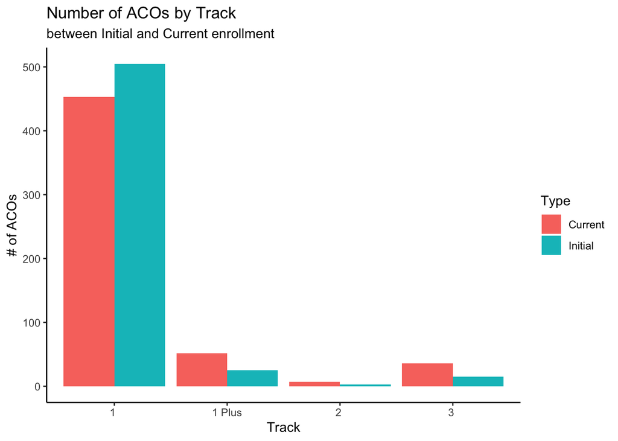

Not surprisingly, we see that the majority of ACOs operate within Track 1, which is less risky than the other 3 tracks.

However, a small portion of ACOs that Initially started in Track one are gradually moving to Track 1 Plus and Track 3. This may be due to the prospective beneficiary assignment.

We can try to look at the flow from the initial distribution of tracks to the current tracks through this alluvial diagram.

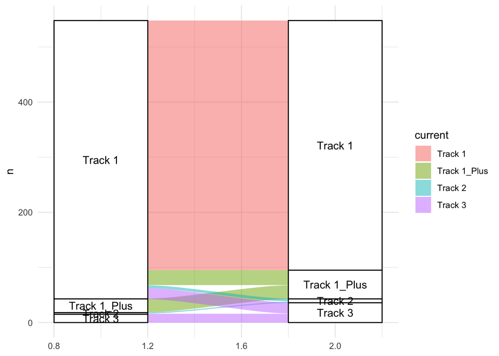

## Generated Total Savings / Losses

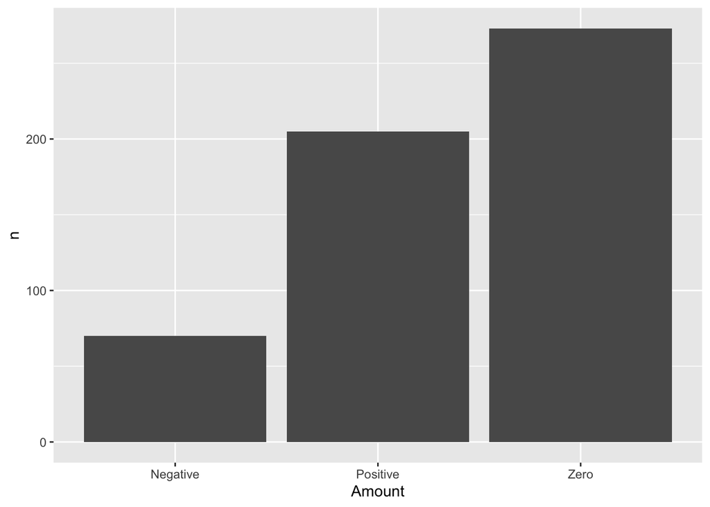

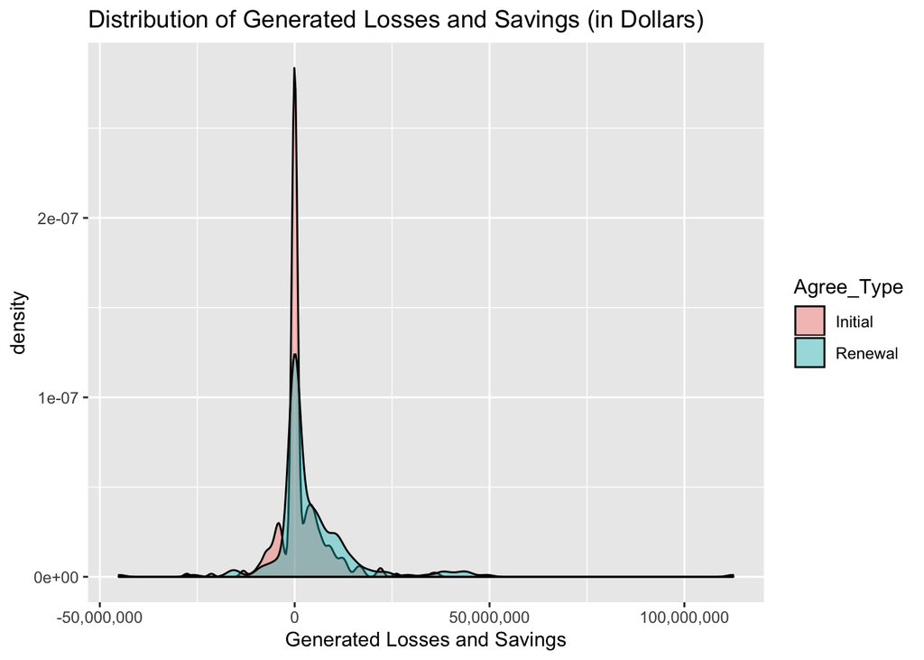

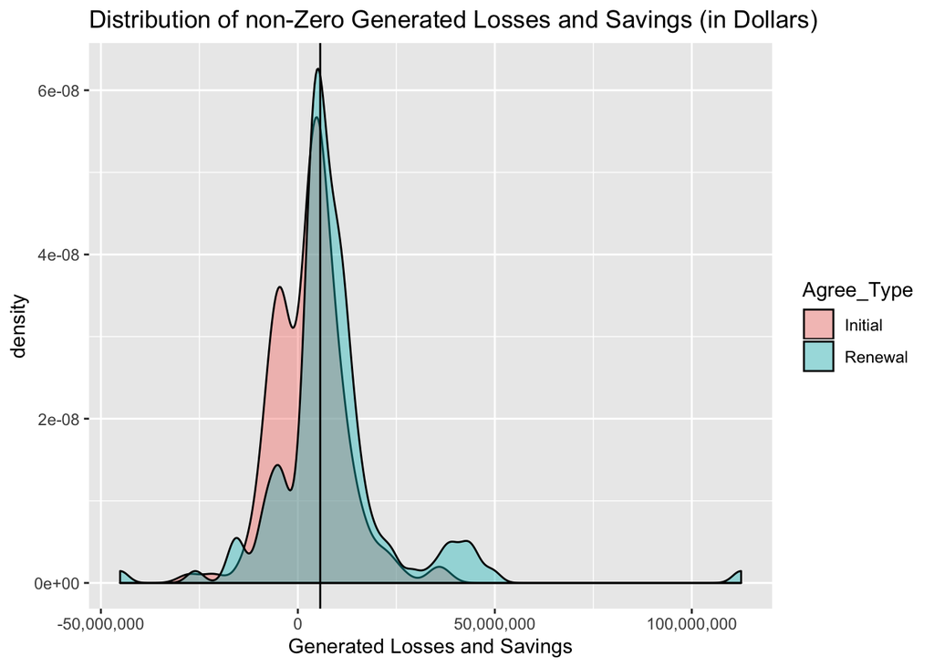

### How many states does a single ACO operate in?

As you can see, a single ACO can operate in multiple states. Here we try to explore the variation of states each ACO operates in.

```
##     ACO_State ACO_ID Agree_Type
## 1          FL  A1001    Renewal
## 2      NY, NJ  A1002    Renewal
## 3      NJ, NY  A1006    Renewal
## 4  NH, ME, MA  A1021    Renewal
## 5          AZ  A1023    Renewal
## 6          NJ  A1026    Renewal
## 7          FL  A1027    Renewal
## 8          CA  A1032    Renewal
## 9          IL  A1033    Renewal
## 10     TX, NJ  A1037    Renewal
```

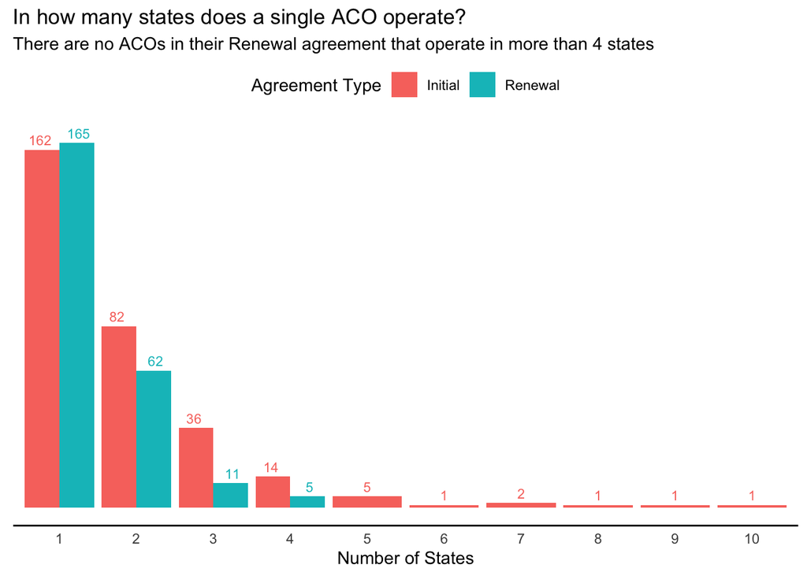

#### Multi-state ACOs

```
##                                 ACO_State
## 1      MI, TX, OH, VA, WI, FL, WA, IL, MO
## 2  PA, NJ, MD, WV, CT, AL, NH, KY, FL, DE
## 3                      NJ, FL, TX, PA, MD
## 4              WA, ND, GU, OR, ID, SD, CO
## 5                      IA, NE, IL, WV, WI
## 6              IL, GA, NV, AL, KY, NM, TX
## 7                      IL, KY, GA, TN, IN
## 8                  TX, FL, SC, CT, CA, VA
## 9          IL, DC, AR, MI, KY, RI, MD, FL
## 10                     FL, OH, PA, MA, NJ
## 11                     TN, MI, IL, MS, AR
##                                                       ACO_Name
## 1                          USMM ACCOUNTABLE CARE PARTNERS, LLC
## 2                                  Genesis Healthcare ACO, LLC
## 3                     Orange Accountable Care Organization LLC
## 4                                               CPSI ACO 2 LLC
## 5                                               CPSI ACO 7 LLC
## 6                                         Care Pledge Alliance
## 7                                   VillageMD Chicago ACO, LLC
## 8                      Independent Physicians Accountable Care
## 9  Accountable Care Coalition of Community Health Centers, LLC
## 10                         Steward National Care Network, Inc.
## 11                    Saint Francis Hospital Medicare ACO, LLC
```

```
## [1] "WA" "ND" "GU" "OR" "ID" "SD" "CO"
```

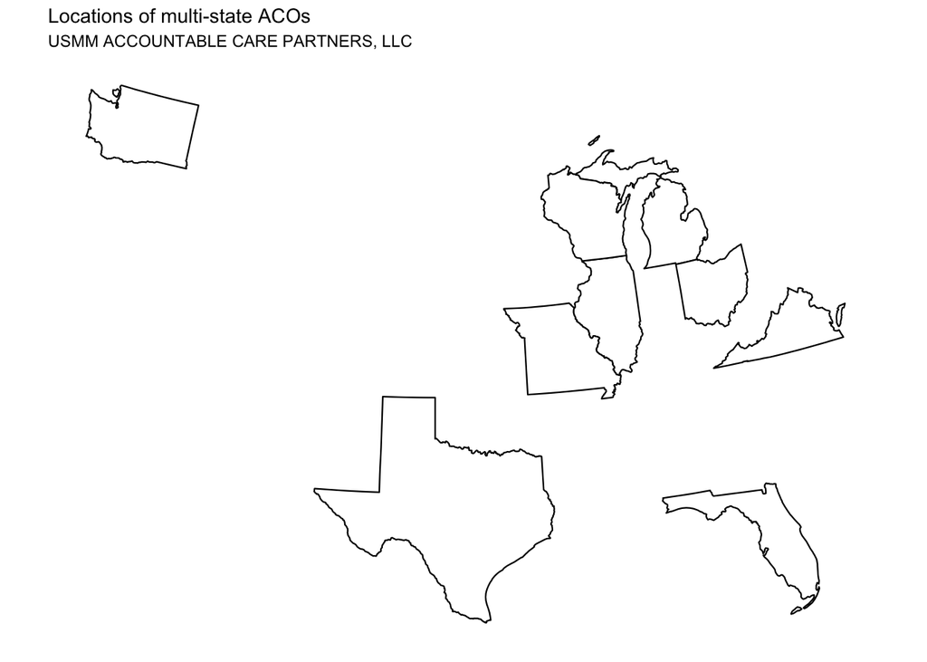

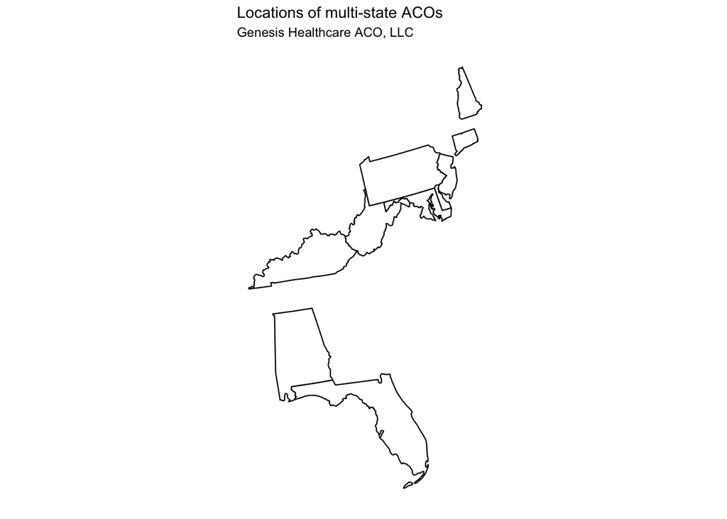

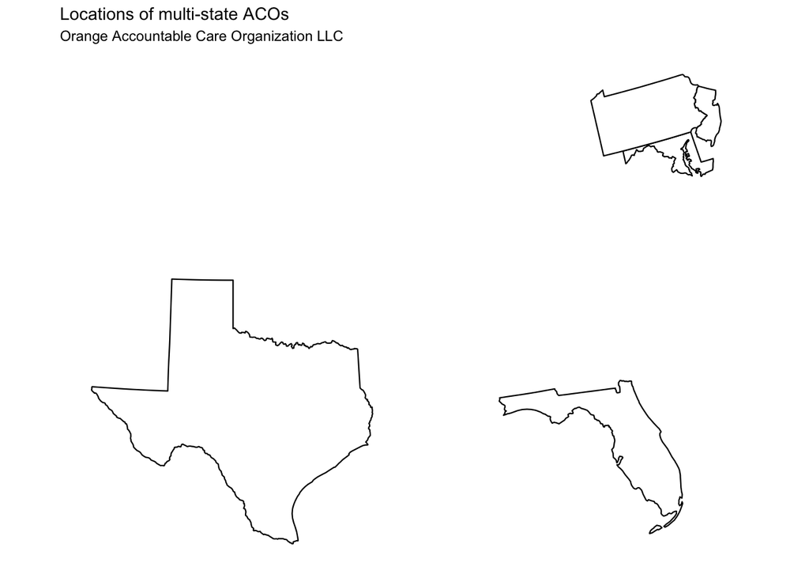

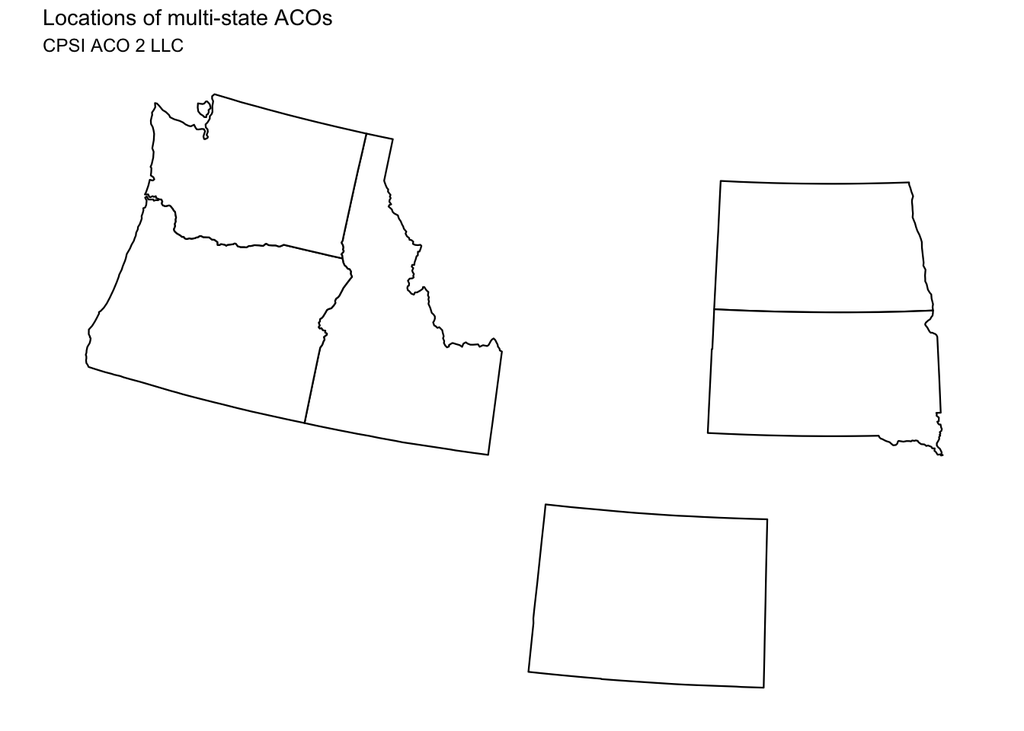

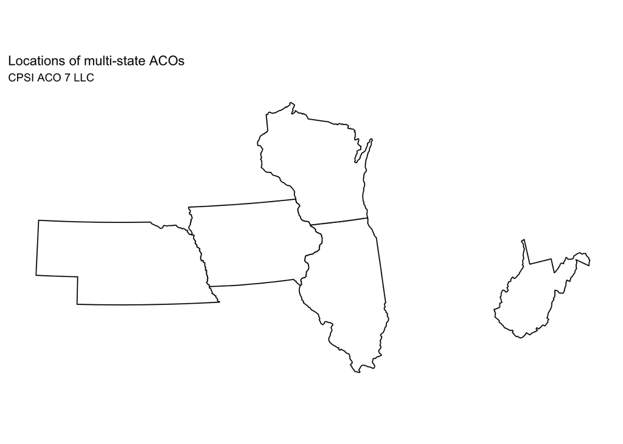

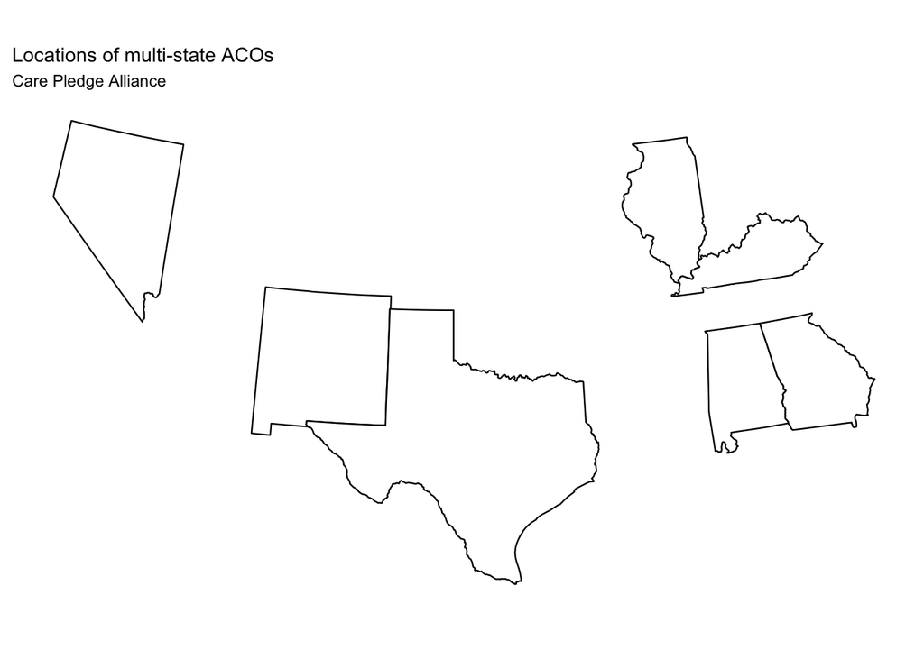

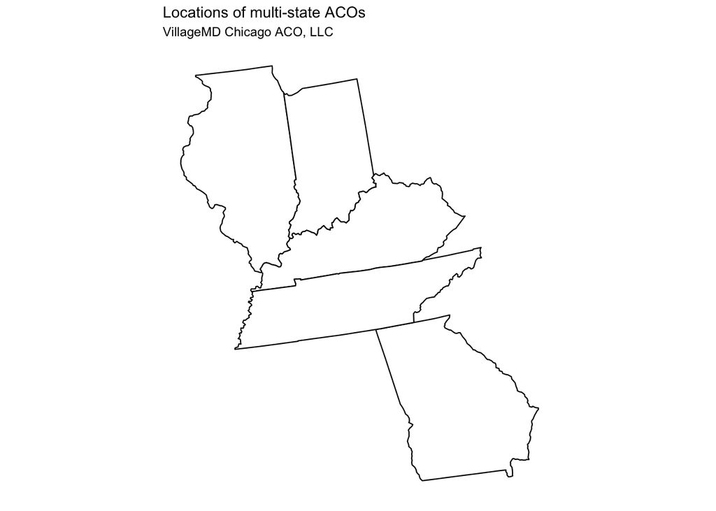

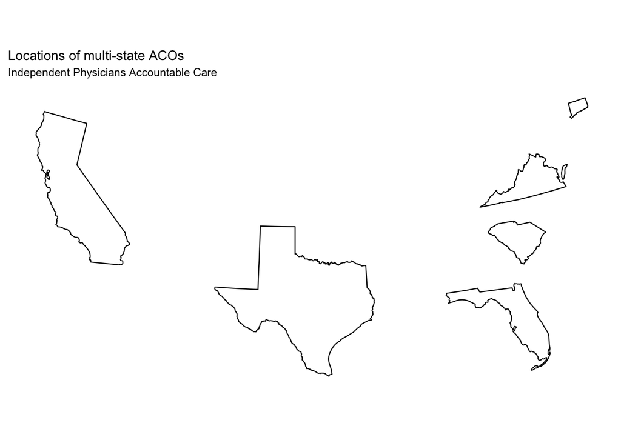

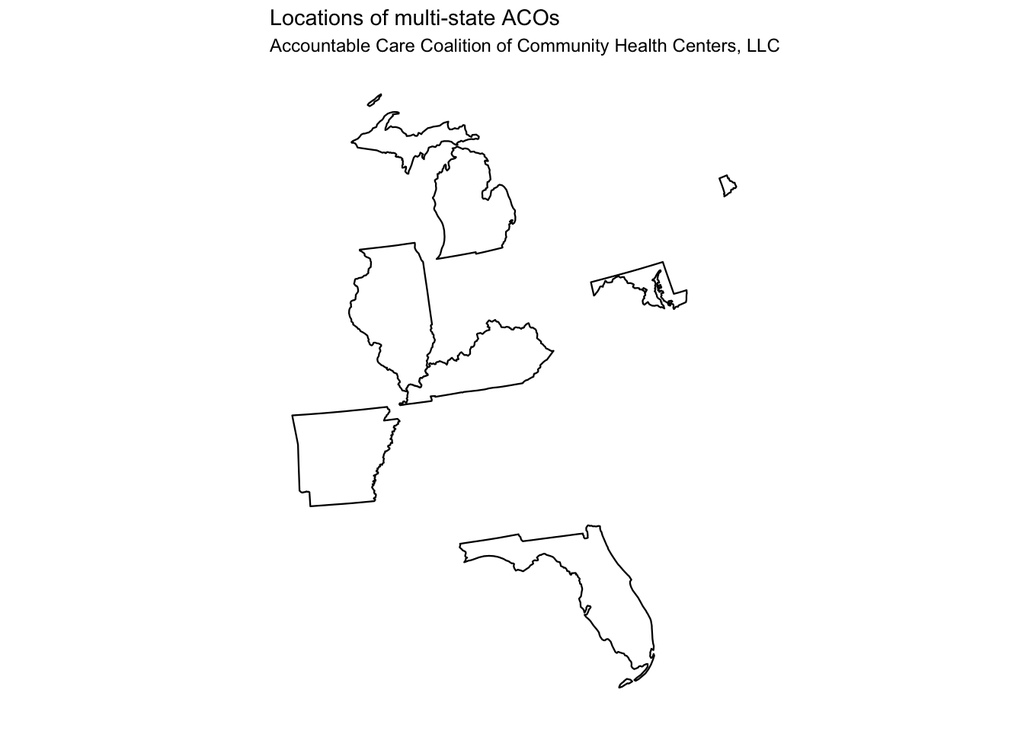

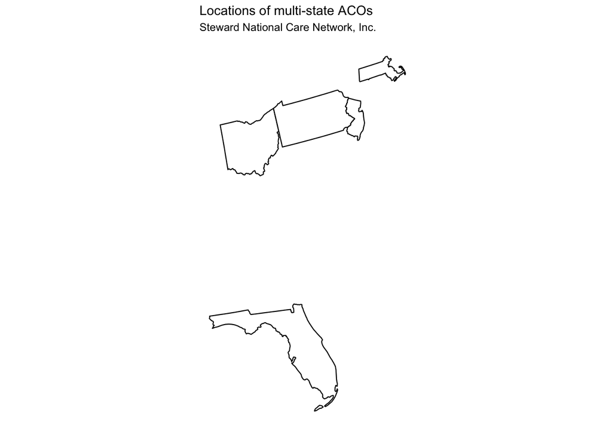

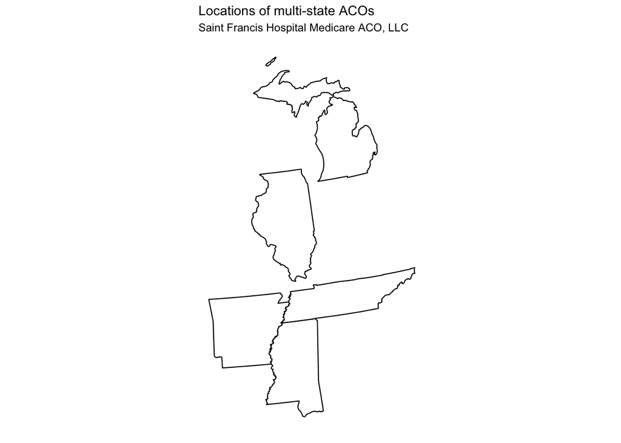

#### Single-state ACOs

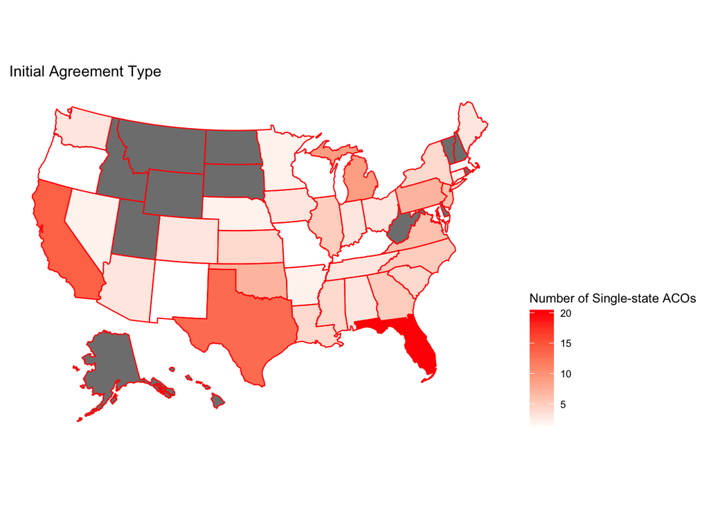

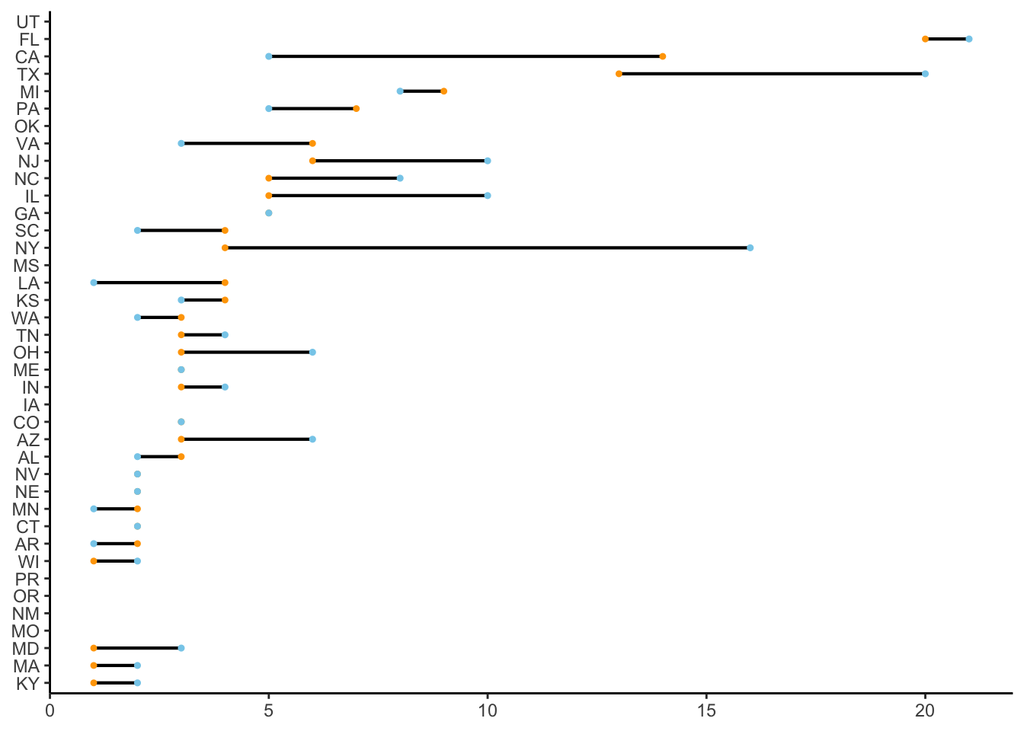

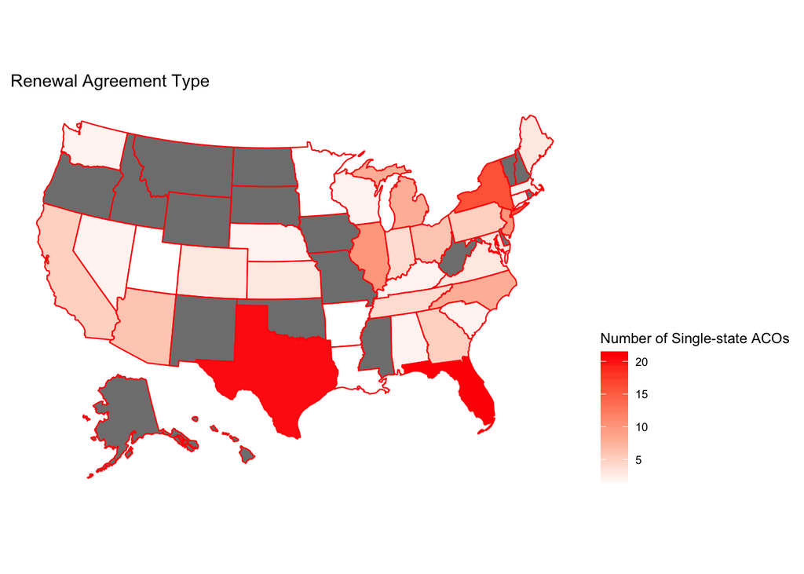

Observations:

- Track two is not very popular
- Most ACOs stay in Track 1
- Those who move from Track 1 go to Track 1+ or Track 3

## Quality Performance Standard (QPS)

For the 2018 performance year, any ACO that did not completely report quality data did not meet the quality performance standard.

An ACO must meet the quality performance standard to be eligible to share in any savings generated.

In 2018, only 2 ACOs did not meet QPS Standard.

```
## # A tibble: 2 x 2
##   Met_QPS     n
##     <int> <int>
## 1       0     2
## 2       1   546
```

```
##                               ACO_Name QualScore
## 1 Physician Partners of Western PA LLC    0.4545
## 2      Accountable Care of Nevada, LLC    0.4545
```

## Quality score:

In Performance Year 1 of an ACO’s first agreement period, the quality score is 100% if all measures were completely reported and less than 100% if one or more measures were not completely reported.

Beyond Performance Year 1 of an ACO’s first agreement period, the quality score will be determined not only by whether all measures were completely reported but also on their performance against established benchmarks and on quality improvement.

```
##   ACO_ID Agree_Type QualScore Initial_Start_Date         current
## 1  A1001    Renewal    0.9084         2012-07-01 Current_Track_1
## 2  A1002    Renewal    0.8503         2012-04-01 Current_Track_1
## 3  A1006    Renewal    0.8937         2012-04-01 Current_Track_1
## 4  A1021    Renewal    0.8752         2012-07-01 Current_Track_1
## 5  A1023    Renewal    0.8585         2012-04-01 Current_Track_1
##           initial Initial_Start_Year
## 1 Initial_Track_1               2012
## 2 Initial_Track_1               2012
## 3 Initial_Track_1               2012
## 4 Initial_Track_1               2012
## 5 Initial_Track_1               2012
```

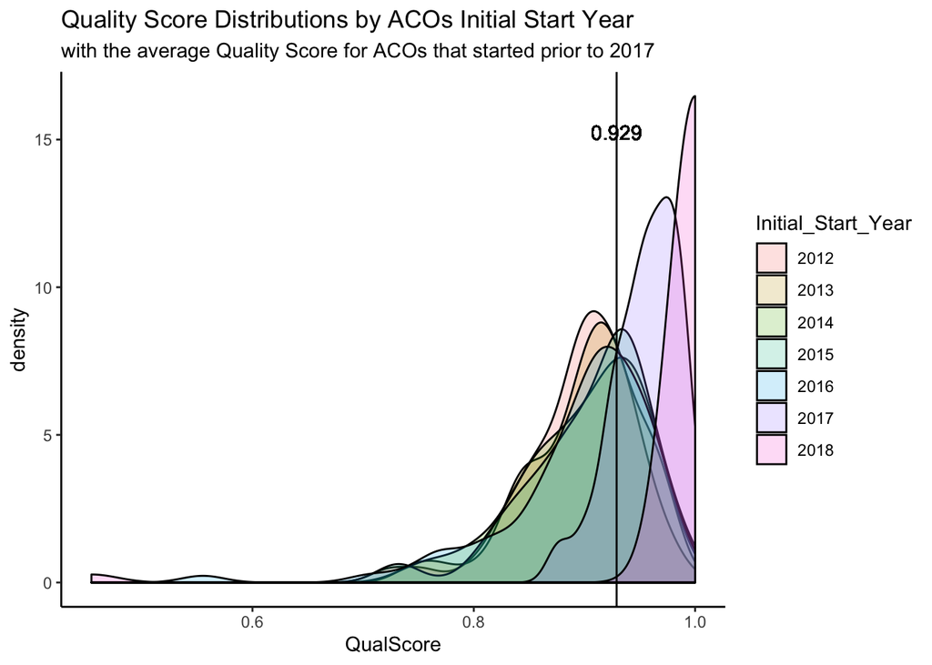

As we see in the graph, quality for those who started in 2017 and 2018 (within their first year), the quality scores are often higher, since the score is primarily around completion of reporting.